# Cyclistic Bike-Share Analysis

Joseph Wilson

2025-01-17

## Introduction

As a part of obtaining my [Google Data Analytics Professional Certificate](https://www.coursera.org/professional-certificates/google-data-analytics), I have completed this capstone project.

In order to answer the business questions, I followed the steps of the data analysis:

- Ask
- Prepare
- Process
- Analyze
- Share
- Act

The tools I used include the [R programming language](https://www.r-project.org/) and the [RStudio IDE](https://posit.co/download/rstudio-desktop/).

## Scenario

You are a junior data analyst working on the marketing analyst team at Cyclistic, a bike-share company in Chicago. The director of marketing believes the company’s future success depends on maximizing the number of annual memberships. Therefore, your team wants to understand how casual riders and annual members use Cyclistic bikes differently. From these insights, your team will design a new marketing strategy to convert casual riders into annual members. But first, Cyclistic executives must approve your recommendations, so they must be backed up with compelling data insights and professional data visualizations.

The director of marketing’s goal is to design marketing strategies aimed at converting casual riders into annual members. In order to do that, however, the team needs to better understand how annual members and casual riders differ, why casual riders would buy a membership, and how digital media could affect their marketing tactics. The team is interested in analyzing the Cyclistic historical bike trip data to identify trends.

## Ask

Three questions will guide the future marketing program:

1. How do annual members and casual riders use Cyclistic bikes differently?
2. Why would casual riders buy Cyclistic annual memberships?
3. How can Cyclistic use digital media to influence casual riders to become members?

## Prepare

I will use Cyclistic’s historical trip data to analyze and identify trends.

Cyclistic is a fictional company. Divvy is an actual bike company in Chicago that provides trip data that can be used to complete the business task. I downloaded the Divvy trip data from all 12 months of 2024 [here](https://divvy-tripdata.s3.amazonaws.com/index.html). The data has been made available by Motivate International Inc. under this [license](https://divvybikes.com/data-license-agreement).

Now, I will prepare the data for analysis.

```r
# install and load packages
install.packages("tidyverse", repos="http://cran.us.r-project.org")
install.packages("geosphere", repos="http://cran.us.r-project.org")
install.packages("leaflet", repos="http://cran.us.r-project.org")
library(tidyverse)
library(geosphere)
library(leaflet)
```

```r
# import the trip data for all 12 months
jan2024 <- read.csv("data/2024-tripdata-raw/202401-divvy-tripdata.csv")
feb2024 <- read.csv("data/2024-tripdata-raw/202402-divvy-tripdata.csv")
mar2024 <- read.csv("data/2024-tripdata-raw/202403-divvy-tripdata.csv")
apr2024 <- read.csv("data/2024-tripdata-raw/202404-divvy-tripdata.csv")
may2024 <- read.csv("data/2024-tripdata-raw/202405-divvy-tripdata.csv")
jun2024 <- read.csv("data/2024-tripdata-raw/202406-divvy-tripdata.csv")
jul2024 <- read.csv("data/2024-tripdata-raw/202407-divvy-tripdata.csv")
aug2024 <- read.csv("data/2024-tripdata-raw/202408-divvy-tripdata.csv")
sep2024 <- read.csv("data/2024-tripdata-raw/202409-divvy-tripdata.csv")
oct2024 <- read.csv("data/2024-tripdata-raw/202410-divvy-tripdata.csv")
nov2024 <- read.csv("data/2024-tripdata-raw/202411-divvy-tripdata.csv")
dec2024 <- read.csv("data/2024-tripdata-raw/202412-divvy-tripdata.csv")
```

```r
# check column names for consistency
colnames(jan2024)
```

```
##  [1] "ride_id"            "rideable_type"      "started_at"
##  [4] "ended_at"           "start_station_name" "start_station_id"
##  [7] "end_station_name"   "end_station_id"     "start_lat"
## [10] "start_lng"          "end_lat"            "end_lng"
## [13] "member_casual"
```

```r
colnames(feb2024) == colnames(jan2024)
```

```
##  [1] TRUE TRUE TRUE TRUE TRUE TRUE TRUE TRUE TRUE TRUE TRUE TRUE TRUE
```

```r
colnames(mar2024) == colnames(jan2024)
```

```
##  [1] TRUE TRUE TRUE TRUE TRUE TRUE TRUE TRUE TRUE TRUE TRUE TRUE TRUE
```

```r
colnames(apr2024) == colnames(jan2024)
```

```
##  [1] TRUE TRUE TRUE TRUE TRUE TRUE TRUE TRUE TRUE TRUE TRUE TRUE TRUE
```

```r
colnames(may2024) == colnames(jan2024)
```

```
##  [1] TRUE TRUE TRUE TRUE TRUE TRUE TRUE TRUE TRUE TRUE TRUE TRUE TRUE
```

```r
colnames(jun2024) == colnames(jan2024)
```

```
##  [1] TRUE TRUE TRUE TRUE TRUE TRUE TRUE TRUE TRUE TRUE TRUE TRUE TRUE
```

```r
colnames(jul2024) == colnames(jan2024)
```

```
##  [1] TRUE TRUE TRUE TRUE TRUE TRUE TRUE TRUE TRUE TRUE TRUE TRUE TRUE
```

```r
colnames(aug2024) == colnames(jan2024)
```

```
##  [1] TRUE TRUE TRUE TRUE TRUE TRUE TRUE TRUE TRUE TRUE TRUE TRUE TRUE
```

```r
colnames(sep2024) == colnames(jan2024)
```

```
##  [1] TRUE TRUE TRUE TRUE TRUE TRUE TRUE TRUE TRUE TRUE TRUE TRUE TRUE
```

```r
colnames(oct2024) == colnames(jan2024)
```

```
##  [1] TRUE TRUE TRUE TRUE TRUE TRUE TRUE TRUE TRUE TRUE TRUE TRUE TRUE
```

```r
colnames(nov2024) == colnames(jan2024)
```

```
##  [1] TRUE TRUE TRUE TRUE TRUE TRUE TRUE TRUE TRUE TRUE TRUE TRUE TRUE
```

```r
colnames(dec2024) == colnames(jan2024)
```

```
##  [1] TRUE TRUE TRUE TRUE TRUE TRUE TRUE TRUE TRUE TRUE TRUE TRUE TRUE
```

```r
# check column data types for consistency
sapply(jan2024, class)
```

```
##            ride_id      rideable_type         started_at           ended_at
##        "character"        "character"        "character"        "character"
## start_station_name   start_station_id   end_station_name     end_station_id
##        "character"        "character"        "character"        "character"
##          start_lat          start_lng            end_lat            end_lng
##          "numeric"          "numeric"          "numeric"          "numeric"
##      member_casual
##        "character"
```

```r
sapply(feb2024, class) == sapply(jan2024, class)
```

```
##            ride_id      rideable_type         started_at           ended_at
##               TRUE               TRUE               TRUE               TRUE
## start_station_name   start_station_id   end_station_name     end_station_id
##               TRUE               TRUE               TRUE               TRUE
##          start_lat          start_lng            end_lat            end_lng
##               TRUE               TRUE               TRUE               TRUE
##      member_casual
##               TRUE
```

```r
sapply(mar2024, class) == sapply(jan2024, class)
```

```
##            ride_id      rideable_type         started_at           ended_at
##               TRUE               TRUE               TRUE               TRUE
## start_station_name   start_station_id   end_station_name     end_station_id
##               TRUE               TRUE               TRUE               TRUE
##          start_lat          start_lng            end_lat            end_lng
##               TRUE               TRUE               TRUE               TRUE
##      member_casual
##               TRUE
```

```r
sapply(apr2024, class) == sapply(jan2024, class)
```

```
##            ride_id      rideable_type         started_at           ended_at
##               TRUE               TRUE               TRUE               TRUE
## start_station_name   start_station_id   end_station_name     end_station_id
##               TRUE               TRUE               TRUE               TRUE
##          start_lat          start_lng            end_lat            end_lng
##               TRUE               TRUE               TRUE               TRUE
##      member_casual
##               TRUE
```

```r
sapply(may2024, class) == sapply(jan2024, class)
```

```
##            ride_id      rideable_type         started_at           ended_at
##               TRUE               TRUE               TRUE               TRUE
## start_station_name   start_station_id   end_station_name     end_station_id
##               TRUE               TRUE               TRUE               TRUE
##          start_lat          start_lng            end_lat            end_lng
##               TRUE               TRUE               TRUE               TRUE
##      member_casual
##               TRUE
```

```r
sapply(jun2024, class) == sapply(jan2024, class)
```

```
##            ride_id      rideable_type         started_at           ended_at
##               TRUE               TRUE               TRUE               TRUE
## start_station_name   start_station_id   end_station_name     end_station_id
##               TRUE               TRUE               TRUE               TRUE
##          start_lat          start_lng            end_lat            end_lng
##               TRUE               TRUE               TRUE               TRUE
##      member_casual
##               TRUE
```

```r
sapply(jul2024, class) == sapply(jan2024, class)
```

```
##            ride_id      rideable_type         started_at           ended_at
##               TRUE               TRUE               TRUE               TRUE
## start_station_name   start_station_id   end_station_name     end_station_id
##               TRUE               TRUE               TRUE               TRUE
##          start_lat          start_lng            end_lat            end_lng
##               TRUE               TRUE               TRUE               TRUE
##      member_casual
##               TRUE
```

```r
sapply(aug2024, class) == sapply(jan2024, class)
```

```
##            ride_id      rideable_type         started_at           ended_at
##               TRUE               TRUE               TRUE               TRUE
## start_station_name   start_station_id   end_station_name     end_station_id
##               TRUE               TRUE               TRUE               TRUE
##          start_lat          start_lng            end_lat            end_lng
##               TRUE               TRUE               TRUE               TRUE
##      member_casual
##               TRUE
```

```r
sapply(sep2024, class) == sapply(jan2024, class)
```

```
##            ride_id      rideable_type         started_at           ended_at
##               TRUE               TRUE               TRUE               TRUE
## start_station_name   start_station_id   end_station_name     end_station_id
##               TRUE               TRUE               TRUE               TRUE
##          start_lat          start_lng            end_lat            end_lng
##               TRUE               TRUE               TRUE               TRUE
##      member_casual
##               TRUE
```

```r
sapply(oct2024, class) == sapply(jan2024, class)
```

```
##            ride_id      rideable_type         started_at           ended_at
##               TRUE               TRUE               TRUE               TRUE
## start_station_name   start_station_id   end_station_name     end_station_id
##               TRUE               TRUE               TRUE               TRUE
##          start_lat          start_lng            end_lat            end_lng
##               TRUE               TRUE               TRUE               TRUE
##      member_casual
##               TRUE
```

```r
sapply(nov2024, class) == sapply(jan2024, class)
```

```
##            ride_id      rideable_type         started_at           ended_at
##               TRUE               TRUE               TRUE               TRUE
## start_station_name   start_station_id   end_station_name     end_station_id
##               TRUE               TRUE               TRUE               TRUE
##          start_lat          start_lng            end_lat            end_lng
##               TRUE               TRUE               TRUE               TRUE
##      member_casual
##               TRUE
```

```r
sapply(dec2024, class) == sapply(jan2024, class)
```

```
##            ride_id      rideable_type         started_at           ended_at
##               TRUE               TRUE               TRUE               TRUE
## start_station_name   start_station_id   end_station_name     end_station_id
##               TRUE               TRUE               TRUE               TRUE
##          start_lat          start_lng            end_lat            end_lng
##               TRUE               TRUE               TRUE               TRUE
##      member_casual
##               TRUE
```

There being no `FALSE` values confirm that all the column names and data types match up across all data frames.

Therefore, the data frames can be merged into one data frame without any problems.

```r
# merge the data frames into one data frame
tripdata <- bind_rows(jan2024, feb2024, mar2024, apr2024, may2024, jun2024,
                      jul2024, aug2024, sep2024, oct2024, nov2024, dec2024)
```

## Process

Now, I will process the data to be used for analysis.

```r
# check the merged data
head(tripdata)
```

```
##            ride_id rideable_type          started_at            ended_at
## 1 C1D650626C8C899A electric_bike 2024-01-12 15:30:27 2024-01-12 15:37:59
## 2 EECD38BDB25BFCB0 electric_bike 2024-01-08 15:45:46 2024-01-08 15:52:59
## 3 F4A9CE78061F17F7 electric_bike 2024-01-27 12:27:19 2024-01-27 12:35:19
## 4 0A0D9E15EE50B171  classic_bike 2024-01-29 16:26:17 2024-01-29 16:56:06
## 5 33FFC9805E3EFF9A  classic_bike 2024-01-31 05:43:23 2024-01-31 06:09:35
## 6 C96080812CD285C5  classic_bike 2024-01-07 11:21:24 2024-01-07 11:30:03
##           start_station_name start_station_id          end_station_name
## 1          Wells St & Elm St     KA1504000135  Kingsbury St & Kinzie St
## 2          Wells St & Elm St     KA1504000135  Kingsbury St & Kinzie St
## 3          Wells St & Elm St     KA1504000135  Kingsbury St & Kinzie St
## 4     Wells St & Randolph St     TA1305000030 Larrabee St & Webster Ave
## 5 Lincoln Ave & Waveland Ave            13253  Kingsbury St & Kinzie St
## 6          Wells St & Elm St     KA1504000135  Kingsbury St & Kinzie St
##   end_station_id start_lat start_lng  end_lat   end_lng member_casual
## 1   KA1503000043  41.90327 -87.63474 41.88918 -87.63851        member
## 2   KA1503000043  41.90294 -87.63444 41.88918 -87.63851        member
## 3   KA1503000043  41.90295 -87.63447 41.88918 -87.63851        member
## 4          13193  41.88430 -87.63396 41.92182 -87.64414        member
## 5   KA1503000043  41.94880 -87.67528 41.88918 -87.63851        member
## 6   KA1503000043  41.90322 -87.63432 41.88918 -87.63851        member
```

```r
str(tripdata)
```

```
## 'data.frame':    5860568 obs. of  13 variables:
##  $ ride_id           : chr  "C1D650626C8C899A" "EECD38BDB25BFCB0" "F4A9CE78061F17F7" "0A0D9E15EE50B171" ...
##  $ rideable_type     : chr  "electric_bike" "electric_bike" "electric_bike" "classic_bike" ...
##  $ started_at        : chr  "2024-01-12 15:30:27" "2024-01-08 15:45:46" "2024-01-27 12:27:19" "2024-01-29 16:26:17" ...
##  $ ended_at          : chr  "2024-01-12 15:37:59" "2024-01-08 15:52:59" "2024-01-27 12:35:19" "2024-01-29 16:56:06" ...
##  $ start_station_name: chr  "Wells St & Elm St" "Wells St & Elm St" "Wells St & Elm St" "Wells St & Randolph St" ...
##  $ start_station_id  : chr  "KA1504000135" "KA1504000135" "KA1504000135" "TA1305000030" ...
##  $ end_station_name  : chr  "Kingsbury St & Kinzie St" "Kingsbury St & Kinzie St" "Kingsbury St & Kinzie St" "Larrabee St & Webster Ave" ...
##  $ end_station_id    : chr  "KA1503000043" "KA1503000043" "KA1503000043" "13193" ...
##  $ start_lat         : num  41.9 41.9 41.9 41.9 41.9 ...
##  $ start_lng         : num  -87.6 -87.6 -87.6 -87.6 -87.7 ...
##  $ end_lat           : num  41.9 41.9 41.9 41.9 41.9 ...
##  $ end_lng           : num  -87.6 -87.6 -87.6 -87.6 -87.6 ...
##  $ member_casual     : chr  "member" "member" "member" "member" ...
```

```r
# convert character columns to date-time columns
tripdata$started_at <- as.POSIXct(tripdata$started_at)
tripdata$ended_at <- as.POSIXct(tripdata$ended_at)
```

```r
# create new columns from date-time
tripdata <- tripdata %>%
  mutate(
    year = year(started_at),
    month = month(started_at, label = TRUE),
    day = day(started_at),
    day_of_week = wday(started_at, label = TRUE),
    start_time = hour(started_at),
    trip_length = as.numeric(difftime(ended_at, started_at, units = "mins"))
  )
```

```r
# create column for distance traveled in km
tripdata <- tripdata %>%
  mutate(
    trip_distance = distVincentySphere(
      cbind(start_lng, start_lat), cbind(end_lng, end_lat)) / 1000
  )
```

```r
# clean by removing data where the trip length is 0 or negative and where the trip distance is NA
tripdata_clean <- tripdata %>%
  filter(trip_length > 0 & !is.na(trip_distance))
```

```r
# check the cleaned data
str(tripdata_clean)
```

```
## 'data.frame':    5852613 obs. of  20 variables:
##  $ ride_id           : chr  "C1D650626C8C899A" "EECD38BDB25BFCB0" "F4A9CE78061F17F7" "0A0D9E15EE50B171" ...
##  $ rideable_type     : chr  "electric_bike" "electric_bike" "electric_bike" "classic_bike" ...
##  $ started_at        : POSIXct, format: "2024-01-12 15:30:27" "2024-01-08 15:45:46" ...
##  $ ended_at          : POSIXct, format: "2024-01-12 15:37:59" "2024-01-08 15:52:59" ...
##  $ start_station_name: chr  "Wells St & Elm St" "Wells St & Elm St" "Wells St & Elm St" "Wells St & Randolph St" ...
##  $ start_station_id  : chr  "KA1504000135" "KA1504000135" "KA1504000135" "TA1305000030" ...
##  $ end_station_name  : chr  "Kingsbury St & Kinzie St" "Kingsbury St & Kinzie St" "Kingsbury St & Kinzie St" "Larrabee St & Webster Ave" ...
##  $ end_station_id    : chr  "KA1503000043" "KA1503000043" "KA1503000043" "13193" ...
##  $ start_lat         : num  41.9 41.9 41.9 41.9 41.9 ...
##  $ start_lng         : num  -87.6 -87.6 -87.6 -87.6 -87.7 ...
##  $ end_lat           : num  41.9 41.9 41.9 41.9 41.9 ...
##  $ end_lng           : num  -87.6 -87.6 -87.6 -87.6 -87.6 ...
##  $ member_casual     : chr  "member" "member" "member" "member" ...
##  $ year              : num  2024 2024 2024 2024 2024 ...
##  $ month             : Ord.factor w/ 12 levels "Jan"<"Feb"<"Mar"<..: 1 1 1 1 1 1 1 1 1 1 ...
##  $ day               : int  12 8 27 29 31 7 5 4 1 3 ...
##  $ day_of_week       : Ord.factor w/ 7 levels "Sun"<"Mon"<"Tue"<..: 6 2 7 2 4 1 6 5 2 4 ...
##  $ start_time        : int  15 15 12 16 5 11 14 18 14 19 ...
##  $ trip_length       : num  7.53 7.22 8 29.82 26.2 ...
##  $ trip_distance     : num  1.6 1.57 1.57 4.26 7.3 ...
```

This confirms that the data frame contains the correct column names and data types, as well as the cleaned data.

## Analyze

Now, I will analyze the data for trends, relationships, and insights.

```r
# 1. member vs. casual total trips
tripdata_clean %>%
  group_by(member_casual) %>%
  summarize(number_of_trips = n(),
            percentage_of_total_trips = n() / nrow(tripdata_clean) * 100)
```

```
## # A tibble: 2 × 3
##   member_casual number_of_trips percentage_of_total_trips
##   <chr>                   <int>                     <dbl>
## 1 casual                2145516                      36.7
## 2 member                3707097                      63.3
```

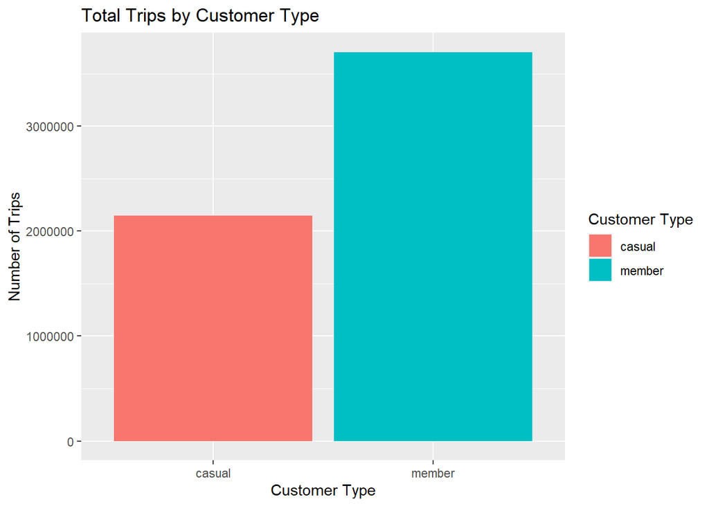

```r
ggplot(data = tripdata_clean) +
  geom_bar(mapping = aes(x = member_casual, fill = member_casual)) +
  scale_y_continuous(labels = function(x) format(x, scientific = FALSE)) +
  labs(title = "Total Trips by Customer Type",
       fill = "Customer Type",
       x = "Customer Type",
       y = "Number of Trips")
```

```r
# 2. member vs. casual bike types
tripdata_clean %>%
  group_by(rideable_type, member_casual) %>%
  summarize(number_of_trips = n(),
            percentage_of_total_trips = n() / nrow(tripdata_clean) * 100)
```

```
## # A tibble: 6 × 4
## # Groups:   rideable_type [3]
##   rideable_type    member_casual number_of_trips percentage_of_total_trips
##   <chr>            <chr>                   <int>                     <dbl>
## 1 classic_bike     casual                 969050                     16.6
## 2 classic_bike     member                1759276                     30.1
## 3 electric_bike    casual                1091251                     18.6
## 4 electric_bike    member                1888699                     32.3
## 5 electric_scooter casual                  85215                      1.46
## 6 electric_scooter member                  59122                      1.01
```

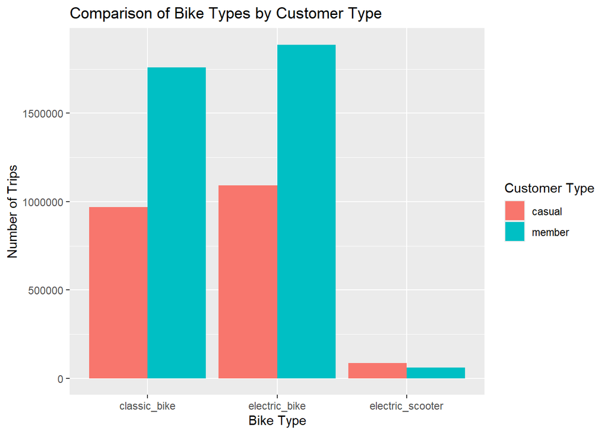

```r
ggplot(data = tripdata_clean) +
  geom_bar(mapping = aes(x = rideable_type, fill = member_casual),
           position = "dodge") +
  labs(title = "Comparison of Bike Types by Customer Type",
       fill = "Customer Type",
       x = "Bike Type",
       y = "Number of Trips")
```

Customers use electric bikes the most, followed by the classic bike then the electric scooter. More members use electric and classic bikes, however, more casual riders use electric scooters.

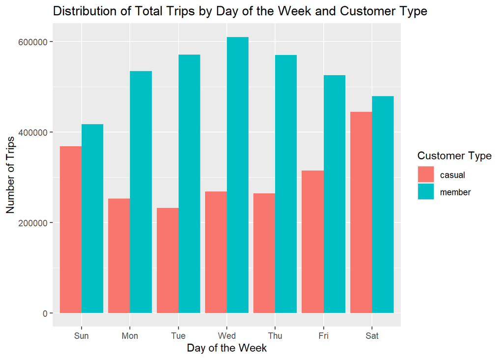

```r
# 3. member vs. casual total number of trips by day of the week
tripdata_clean %>%
  group_by(member_casual, day_of_week) %>%
  summarise(number_of_trips = n(), .groups="drop") %>%
  ggplot() +
  geom_col(aes(x = day_of_week, y = number_of_trips, fill = member_casual),
           position = "dodge") +
  scale_y_continuous(labels = function(x) format(x, scientific = FALSE)) +
  labs(title = "Distribution of Total Trips by Day of the Week and Customer Type",
       fill = "Customer Type",
       x = "Day of the Week",
       y = "Number of Trips")
```

The number of trips made by casual riders increases during the weekends and decreases during the weekdays. The opposite happens for members as the number of trips decreases during the weekends and increases during the weekdays. This may suggest that casual riders use the bikes more for leisure while members use them more for work travel.

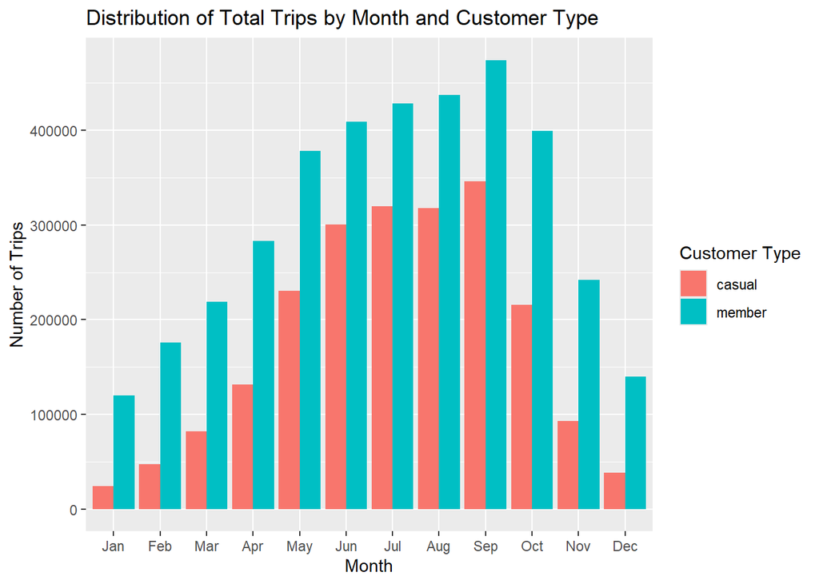

```r
# 4. member vs. casual total number of trips by month
tripdata_clean %>%
  group_by(member_casual, month) %>%
  summarise(number_of_trips = n(), .groups="drop") %>%
  ggplot() +
  geom_col(aes(x = month, y = number_of_trips, fill = member_casual),
           position = "dodge") +
  scale_y_continuous(labels = function(x) format(x, scientific = FALSE)) +
  labs(title = "Distribution of Total Trips by Month and Customer Type",
       fill = "Customer Type",
       x = "Month",
       y = "Number of Trips")
```

For both casual riders and members, the least amount of trips take place in January while the most number of trips take place in September. The number of trips is lowest during the winter and highest during the summer.

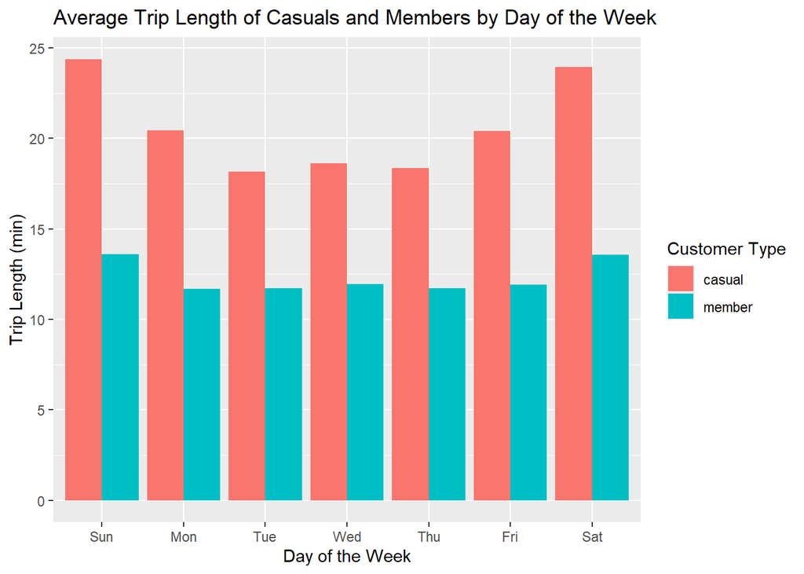

```r
# 5. member vs. casual average trip length by day of the week
tripdata_clean %>%
  group_by(member_casual, day_of_week) %>%
  summarise(average_trip_length = mean(trip_length), .groups="drop") %>%
  ggplot() +
  geom_col(aes(x = day_of_week, y = average_trip_length, fill = member_casual),
           position = "dodge") +
  scale_y_continuous(labels = function(x) format(x, scientific = FALSE)) +
  labs(title = "Average Trip Length of Casuals and Members by Day of the Week",
       fill = "Customer Type",
       x = "Day of the Week",
       y = "Trip Length (min)")
```

On average, casual riders go on longer trips than members. The average trip length of casuals is nearly double that of members on the weekends. The difference in the average between weekends and weekdays is higher for casuals than members. Longer trips may suggest that the casuals use the bikes for leisure.

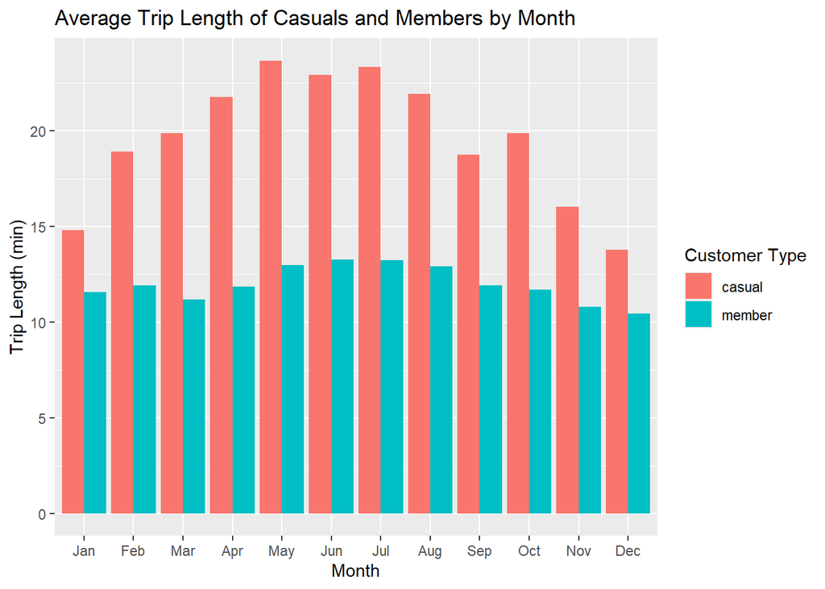

```r
# 6. member vs. casual average trip length by month
tripdata_clean %>%
  group_by(member_casual, month) %>%
  summarise(average_trip_length = mean(trip_length), .groups="drop") %>%
  ggplot() +
  geom_col(aes(x = month, y = average_trip_length, fill = member_casual),
           position = "dodge") +
  scale_y_continuous(labels = function(x) format(x, scientific = FALSE)) +
  labs(title = "Average Trip Length of Casuals and Members by Month",
       fill = "Customer Type",
       x = "Month",
       y = "Trip Length (min)")
```

There is a much wider range in the average trip length of casuals than members throughout the year. The average is higher for casuals the entire year. The average trip length is lowest in the late fall/early winter and highest in the late spring/early summer. Since the average is fairly consistent for members, it suggests that they use the bikes primarily for commuting. The average being higher for casuals during months with weather better suited for outdoor activity suggests that they use the bikes primarily for leisure.

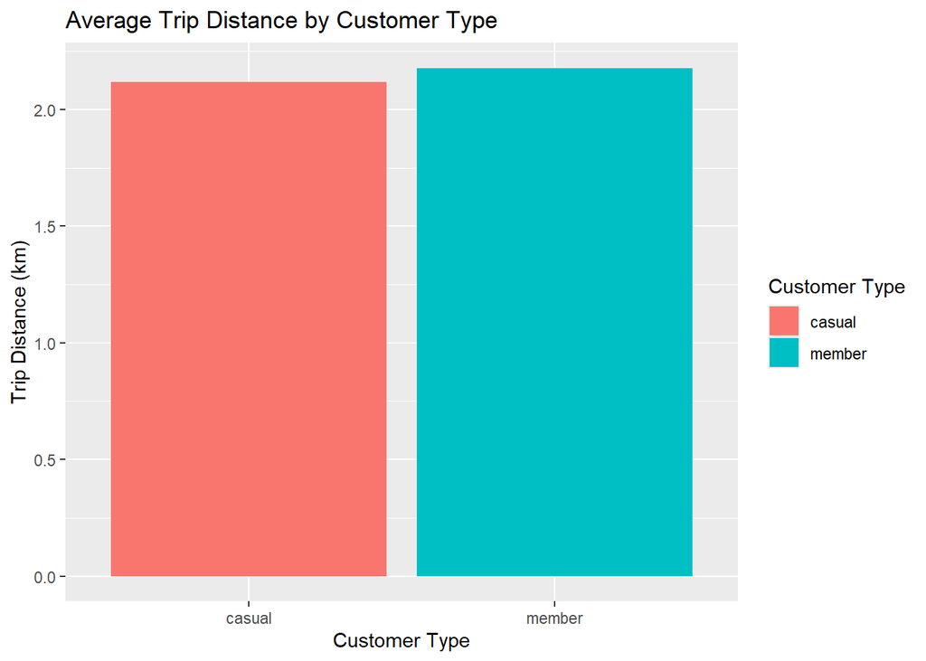

```r
# 7. member vs. casual average trip distance
tripdata_clean %>%
  group_by(member_casual) %>%
  summarise(average_trip_distance = mean(trip_distance), .groups="drop") %>%
  ggplot() +
  geom_col(aes(x = member_casual, y = average_trip_distance, fill = member_casual),
           position = "dodge") +
  scale_y_continuous(labels = function(x) format(x, scientific = FALSE)) +
  labs(title = "Average Trip Distance by Customer Type",
       fill = "Customer Type",
       x = "Customer Type",
       y = "Trip Distance (km)")
```

The average trip distance is fairly similar between casuals and members. Members have a slightly higher average.

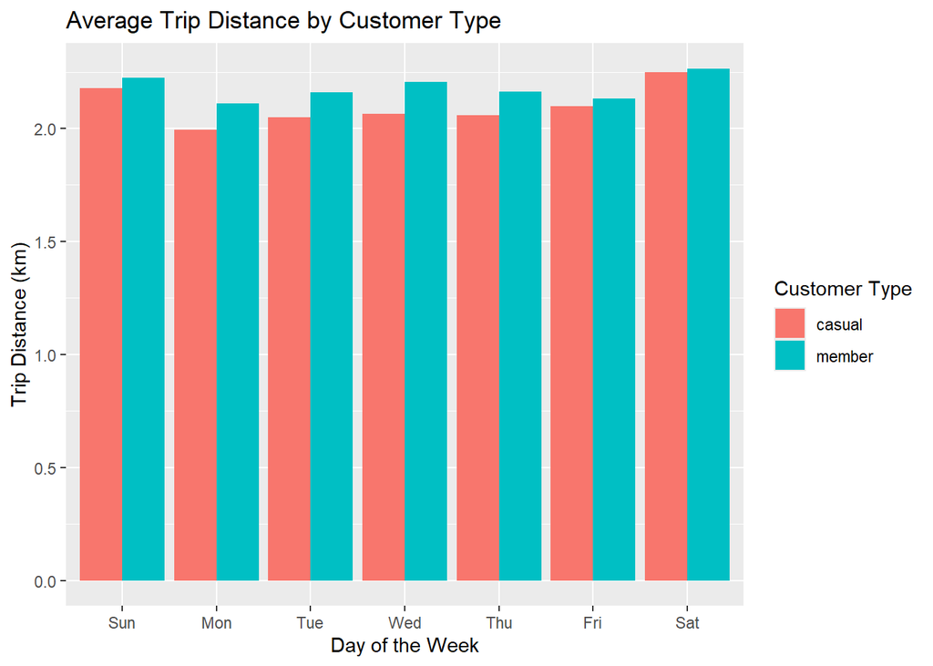

```r
# 8. member vs. casual average trip distance by day of week
tripdata_clean %>%
  group_by(member_casual, day_of_week) %>%
  summarise(average_trip_distance = mean(trip_distance), .groups="drop") %>%
  ggplot() +
  geom_col(aes(x = day_of_week, y = average_trip_distance, fill = member_casual),
           position = "dodge") +
  scale_y_continuous(labels = function(x) format(x, scientific = FALSE)) +
  labs(title = "Average Trip Distance by Customer Type",
       fill = "Customer Type",
       x = "Day of the Week",
       y = "Trip Distance (km)")
```

Casuals have an increase in the average travel distance during the weekends and a decrease during the weekdays. Members have a fairly consistent average throughout the entire week. The increase in casuals during the weekends could be due to using bikes for leisure activities.

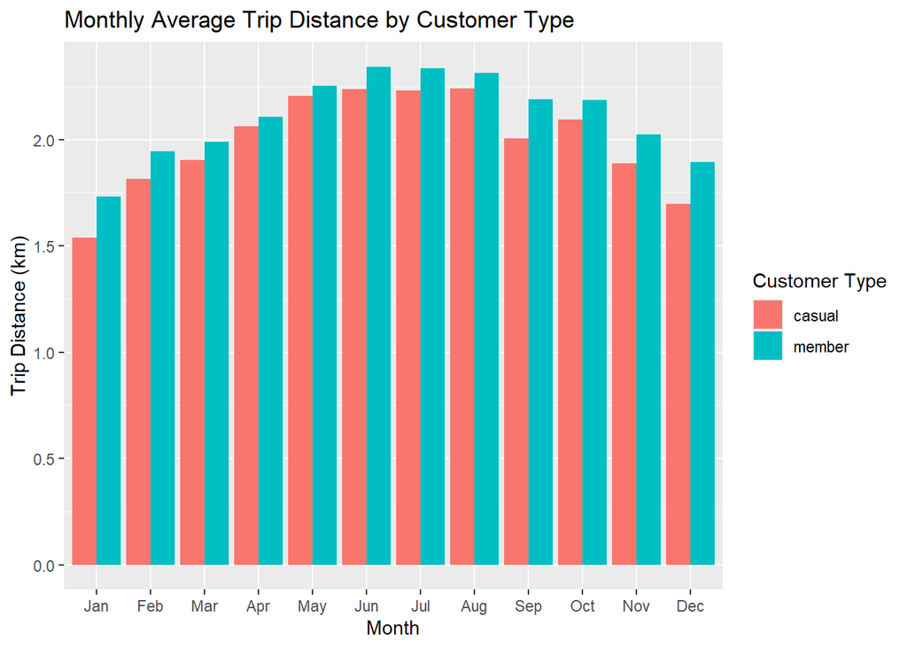

```r
# 9. member vs. casual average trip distance by month
tripdata_clean %>%
  group_by(member_casual, month) %>%
  summarise(average_trip_distance = mean(trip_distance), .groups="drop") %>%
  ggplot() +
  geom_col(aes(x = month, y = average_trip_distance, fill = member_casual),
           position = "dodge") +
  scale_y_continuous(labels = function(x) format(x, scientific = FALSE)) +
  labs(title = "Monthly Average Trip Distance by Customer Type",
       fill = "Customer Type",
       x = "Month",
       y = "Trip Distance (km)")
```

Both members and casuals have an increase in trip distance during the summer and a decrease during the winter.

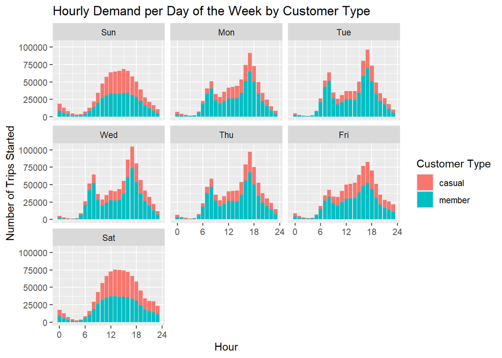

```r
# 10. member vs. casual hourly demand per day
ggplot(data = tripdata_clean) +
  geom_bar(mapping = aes(x = start_time, fill = member_casual)) +
  facet_wrap(~day_of_week) +
  scale_x_continuous(breaks = seq(0, 24, by = 6)) +
  labs(title = "Hourly Demand per Day of the Week by Customer Type",
       fill = "Customer Type",
       x = "Hour",
       y = "Number of Trips Started")
```

During the weekdays, the demand from members peaks before and after work hours. The demand from casuals also increases during those hours but not to the same degree as members. During the weekends, the demand from casuals and members peaks during the early afternoon. From this, members are more likely to use the bikes for their commute than casuals.

```r
# 11. member vs. casual most popular stations
station_popularity <- tripdata_clean %>%
  group_by(start_station_name, start_lng, start_lat, member_casual) %>%
  summarise(usage_count = n(), .groups = "drop")
member_station_popularity <- station_popularity %>%
  filter(member_casual == "member") %>%
  arrange(desc(usage_count)) %>%
  head(10)
casual_station_popularity <- station_popularity %>%
  filter(member_casual == "casual") %>%
  arrange(desc(usage_count)) %>%
  head(10)
# Create the leaflet map
leaflet() %>%
  addTiles() %>%
  # add markers for top 10 stations for members
  addCircleMarkers(
    data = member_station_popularity,
    lng = ~start_lng, lat = ~start_lat,
    radius = ~sqrt(usage_count) / 15,
    color = "blue", fillOpacity = 0.7,
    popup = ~paste0(start_station_name, "<br>Members: ", usage_count)
  ) %>%
  # add markers for top 10 stations for casuals
  addCircleMarkers(
    data = casual_station_popularity,
    lng = ~start_lng, lat = ~start_lat,
    radius = ~sqrt(usage_count) / 15,
    color = "green", fillOpacity = 0.7,
    popup = ~paste0(start_station_name, "<br>Casuals: ", usage_count)
  ) %>%
  addLegend(
    position = "bottomright",
    title = "Customer Type",
    colors = c("blue", "green"),
    labels = c("Members", "Casuals")
  )
```

[interactive chart not shown]

The top 10 most used stations by casuals are located closer to Lake Michigan. The top 10 most used stations by members are located further inland. It appears that casuals mostly use the stations that are near a scenic view for leisure activity while members mostly use stations for commuting within the city.

## Share

From the above visualizations, annual members and casual riders use Cyclistic bikes differently in the following ways:

- Members make up the majority of the total number of trips.
- For members, there is an increase in trips during the weekdays and a decrease during the weekends. For casuals, there is a decrease in trips during the weekdays and an increase during the weekends.
- On average, casuals have a longer trip duration than members. The average for casuals is highest during the weekends while the average for members stays fairly consistent throughout the entire week.
- The average trip duration throughout the year for members stays fairly consistent. For casuals, the average is at its peak during the summer months and lowest during the winter months.
- Members have a slightly larger average trip distance than casuals. The average for members remains fairly consistent throughout the entire week while the average for casuals increases during the weekends.
- During weekdays, hourly demand peaks during typical rush hours. During weekends, hourly demand peaks in the early afternoon. Hourly demand from members is highest on weekdays. Hourly demand from casuals is highest on weekends.
- The most popular stations for casuals are closer to Lake Michigan while the most popular stations for members are further inland.

These findings suggest that casual riders are more likely to use Cyclistic bikes for leisure activity while annual members are more likely to use them for commuting to work.

## Act

Based on my analysis, my top 3 recommendations for maximizing the number of annual memberships include:

1. Focus marketing efforts at stations near Lake Michigan. Maximize the use of banners, digital ads, and staff outreach at these locations during weekends when casual riders are most active.
2. Introduce discounts and/or free trials starting in late spring/early summer. Share promotions in the form of digital ads.
3. During weekdays, highlight the benefits of the annual membership that appeal to people commuting to work. During weekends, highlight the benefits of the annual membership that appeal to people riding bikes for leisure activity.

In the future, I can expand on my findings with data that provides the personally identifiable information of customers. Through this data, I may be able to determine:

- Whether the customer lives near or within the Cyclistic service area.
- Whether the customer is purchasing multiple single passes.

## Conclusion

Thank you for taking the time to follow along and see my process for completing this case study!